# All Star or Not

Gary Wang

4/9/2021

Install Necessary Packages

```r
devtools::install_github("abresler/nbastatR")
```

Import Necessary Packages

```r
library(e1071)
library(nbastatR)
library(devtools)
library(tidyverse)
```

```r
library(class)
library(dplyr)
library(corrplot)
library(NeuralNetTools)
library(neuralnet)
library(png)
```

## (1) Acquire the Data from nbaStatR and Generate our dataframe of desired stats

```r
pull_stats <- game_logs(seasons = 2020:2021)
```

```
## Acquiring NBA basic player game logs for the 2019-20 Regular Season
```

```
## Acquiring NBA basic player game logs for the 2020-21 Regular Season
```

```r
pull_stats2 <- game_logs(seasons = 2021)
```

```
## Acquiring NBA basic player game logs for the 2020-21 Regular Season
```

```r
select_stats <- data.frame(pull_stats$namePlayer, pull_stats$dateGame, pull_stats$pts, pull_stats$ast, pull_stats$treb, pull_stats$stl, pull_stats$blk, pull_stats$pctFG,
                           pull_stats$fta, pull_stats$plusminus, pull_stats$isWin, pull_stats$minutes)
select_stats2 <- data.frame(pull_stats2$namePlayer, pull_stats2$dateGame, pull_stats2$pts, pull_stats2$ast, pull_stats2$treb, pull_stats2$stl, pull_stats2$blk, pull_stats2$pctFG,
                            pull_stats2$fta, pull_stats2$plusminus, pull_stats2$isWin, pull_stats2$minutes)
playerImgs <- data.frame(pull_stats2$namePlayer, pull_stats2$urlPlayerHeadshot)
```

2. Preprocess our data
- filter out games that occur after the all-star break
- group by player name and average the rest of their stats (now per game avgs)
- rename the columns for better readability

## As we will have averaged the stats, our column names are on a per game basis

```r
# Get the games played for each player
add_games_played <- function(games, players, p1, p2) {
  for (player1 in 1:nrow(players)) {
    for (player2 in 1:nrow(games)) {
      if (players[player1, p1] == games[player2, p2]) {
        players[player1, 'gamesPlayed'] <- games[player2, 'n']
      }
    }
  }
  return(players)
}


# Let us get only stats before the All Star Break (Before February 20)
select_stats1 <- select_stats %>% filter(select_stats$pull_stats.dateGame < as.Date('2021-2-28'))
select_stats_2 <- select_stats2 %>% filter(select_stats2$pull_stats2.dateGame < as.Date('2021-2-28'))

# get games played for each player
games_played <- select_stats1 %>% count(select_stats1$pull_stats.namePlayer)
games_played2 <- select_stats_2 %>% count(select_stats_2$pull_stats2.namePlayer)

# Group by player and get their averages
avg_stats <- data.frame(aggregate(.~ pull_stats.namePlayer, select_stats1, mean))
avg_stats2 <- data.frame(aggregate(.~ pull_stats2.namePlayer, select_stats_2, mean))

# Add games played to the dataframe
avg_stats <- add_games_played(games_played, avg_stats, 'pull_stats.namePlayer', 'select_stats1$pull_stats.namePlayer')
avg_stats2 <- add_games_played(games_played2, avg_stats2, 'pull_stats2.namePlayer', 'select_stats_2$pull_stats2.namePlayer')

avg_stats <- avg_stats[c("pull_stats.namePlayer", "pull_stats.pts", "pull_stats.ast", "pull_stats.treb", "pull_stats.stl", "pull_stats.blk", "pull_stats.pctFG",
                         "pull_stats.fta", "pull_stats.plusminus", "pull_stats.isWin", "pull_stats.minutes", "gamesPlayed")]
avg_stats2 <- avg_stats2[c("pull_stats2.namePlayer", "pull_stats2.pts", "pull_stats2.ast", "pull_stats2.treb", "pull_stats2.stl", "pull_stats2.blk", "pull_stats2.pctFG",
                           "pull_stats2.fta", "pull_stats2.plusminus", "pull_stats2.isWin", "pull_stats2.minutes", "gamesPlayed")]

# Rename for better readability
all_players <- avg_stats %>% rename(
                    playerName = pull_stats.namePlayer,
                    ppg = pull_stats.pts,
                    apg = pull_stats.ast,
                    rpg = pull_stats.treb,
                    spg = pull_stats.stl ,
                    bpg = pull_stats.blk,
                    pctFG = pull_stats.pctFG,
                    ftapg = pull_stats.fta,
                    pmpg = pull_stats.plusminus,
                    winPerc = pull_stats.isWin,
                    mpg = pull_stats.minutes
                    )
all_players2 <- avg_stats2 %>% rename(
                    playerName = pull_stats2.namePlayer,
                    ppg = pull_stats2.pts,
                    apg = pull_stats2.ast,
                    rpg = pull_stats2.treb,
                    spg = pull_stats2.stl ,
                    bpg = pull_stats2.blk,
                    pctFG = pull_stats2.pctFG,
                    ftapg = pull_stats2.fta,
                    pmpg = pull_stats2.plusminus,
                    winPerc = pull_stats2.isWin,
                    mpg = pull_stats2.minutes
                    )
all_players <- data.frame(all_players)
all_players2 <- data.frame(all_players2)

all_players
```

```
##                   playerName        ppg       apg        rpg        spg
## 1               Aaron Gordon 14.2716049 3.8024691  7.5555556 0.80246914
## 2              Aaron Holiday  8.8775510 2.8673469  2.0306122 0.74489796
## 3              Aaron Nesmith  4.6875000 0.3750000  2.5625000 0.18750000
## 4                Abdel Nader  6.4264706 0.7352941  1.9411765 0.41176471
## 5                Adam Mokoka  3.0714286 0.5714286  1.0000000 0.35714286
## 6          Admiral Schofield  4.5000000 0.6818182  1.8636364 0.31818182
## 7                 Al Horford 12.5000000 3.9222222  6.8000000 0.81111111
## 8            Al-Farouq Aminu  4.3333333 1.2916667  4.7083333 1.08333333
## 9                 Alec Burks 14.1136364 2.6363636  4.3295455 0.88636364
## 10        Aleksej Pokusevski  3.2941176 1.2352941  3.5294118 0.47058824
## 11            Alen Smailagic  4.5384615 0.9230769  1.8461538 0.23076923
## 12               Alex Caruso  5.4615385 2.0439560  2.1208791 1.08791209
## 13                  Alex Len  7.5733333 0.9333333  5.2400000 0.41333333
## 14          Alfonzo McKinnie  4.5106383 0.3191489  2.7234043 0.51063830
```

[output cut: 1812 more lines]

```r
all_players2
```

```
##                   playerName        ppg         apg        rpg        spg
## 1               Aaron Gordon 13.7894737  4.21052632  7.2105263 0.73684211
## 2              Aaron Holiday  7.5937500  1.75000000  1.3437500 0.56250000
## 3              Aaron Nesmith  4.6875000  0.37500000  2.5625000 0.18750000
## 4                Abdel Nader  6.5714286  0.85714286  2.2857143 0.35714286
## 5                Adam Mokoka  2.7500000  1.00000000  1.0000000 0.50000000
## 6                 Al Horford 14.2173913  3.60869565  6.7826087 0.91304348
## 7            Al-Farouq Aminu  4.3333333  1.66666667  4.3333333 1.33333333
## 8                 Alec Burks 11.3181818  1.95454545  4.5000000 0.72727273
## 9         Aleksej Pokusevski  3.2941176  1.23529412  3.5294118 0.47058824
## 10               Alex Caruso  5.4814815  2.29629630  2.5925926 1.07407407
## 11                  Alex Len  6.5000000  1.00000000  3.6000000 0.40000000
## 12          Alfonzo McKinnie  2.7272727  0.09090909  1.5454545 0.09090909
## 13               Amir Coffey  4.6666667  0.58333333  1.1666667 0.33333333
## 14            Andre Drummond 17.4800000  2.56000000 13.4800000 1.60000000
```

[output cut: 1452 more lines]

3. Let us first analyze the df through Exploratory Data Analysis (EDA)

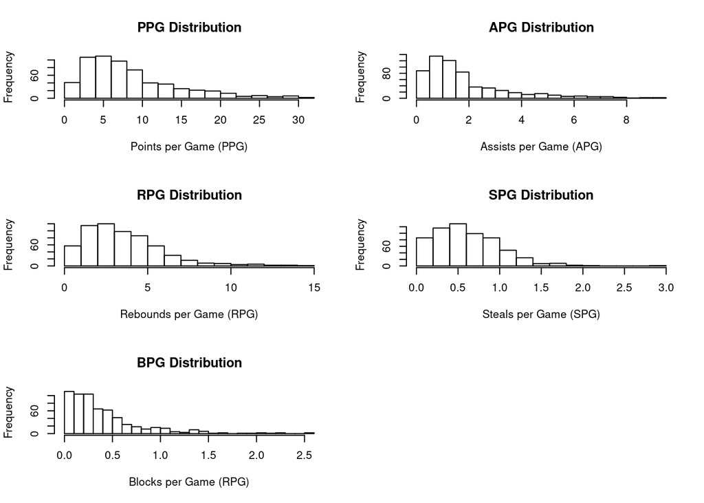

```r
par(mfrow=c(3, 2))
# Let us see the distribution of ppg
hist(as.numeric(all_players$ppg), xlab = "Points per Game (PPG)", main = "PPG Distribution", breaks = 20)
# Let us see the distribution of apg
hist(as.numeric(all_players$apg), xlab = "Assists per Game (APG)", main = "APG Distribution", breaks = 20)
# Let us see the distribution of rpg
hist(as.numeric(all_players$rpg), xlab = "Rebounds per Game (RPG)", main = "RPG Distribution", breaks = 20)
# Let us see the distribution of spg
hist(as.numeric(all_players$spg), xlab = "Steals per Game (SPG)", main = "SPG Distribution", breaks = 20)
# Let us see the distribution of bpg
hist(as.numeric(all_players$bpg), xlab = "Blocks per Game (RPG)", main = "BPG Distribution", breaks = 20)
```

MODELS ——

4. Model 1 KNN to see if we can classify (All Star/Not All Star) Based off of historical All Star Players

```r
# The all star roster for the 2019-2020 season
all_star_roster_2021 <- c('Kevin Durant', 'LeBron James', 'Bradley Beal', 'Giannis Antetokounmpo', 'Kyrie Irving', 'Stephen Curry', 'Kawhi Leonard', 'Luka Doncic',
                          'Jayson Tatum', 'Zion Williamson', 'Nikola Jokic', 'Mike Conley', 'Jaylen Brown', 'James Harden', 'Paul George', 'Zach LaVine', 'Rudy Gobert',
                          'Donovan Mitchell', 'Damian Lillard', 'Julius Randle', 'Domantas Sabonis', 'Nikola Vucevic', 'Chris Paul', 'Devin Booker', 'Ben Simmons', 'Anthony Davis', 'Joel Embiid')
all_star_roster_2020 <- c('Kemba Walker', 'Trae Young', 'Giannis Antetokounmpo', 'Pascal Siakam', 'Joel Embiid', 'Kyle Lowry',
                          'Ben Simmons', 'Jimmy Butler', 'Khris Middleton', 'Bam Adebayo', 'Jayson Tatum', 'Domantas Sabonis',
                          'James Harden', 'Luka Doncic', 'LeBron James', 'Kawhi Leonard', 'Anthony Davis', 'Chris Paul', 'Russell Westbrook',
                          'Damian Lillard', 'Donovan Mitchell', 'Brandon Ingram', 'Nikola Jokic', 'Rudy Gobert', 'Devin Booker')
```

```r
# Identify the true allstars in the 2020 season
add_all_stars <- function(roster, players) {
  for (player in 1:nrow(players)) {
    if (is.element(players[player, 'playerName'], roster)) {
      players[player, 'AllStar'] <- 1
    }
  }
  return(players)
}

# Let us use the all star roster to label the our dataframe as either All Star
unlabeled <- all_players %>% add_column(AllStar = 0)
unlabeled2 <- all_players2 %>% add_column(AllStar = 0)

labeled_players <- add_all_stars(all_star_roster_2021, unlabeled)
labeled_players <- add_all_stars(all_star_roster_2020, labeled_players)
labeled_players
```

```
##                   playerName        ppg       apg        rpg        spg
## 1               Aaron Gordon 14.2716049 3.8024691  7.5555556 0.80246914
## 2              Aaron Holiday  8.8775510 2.8673469  2.0306122 0.74489796
## 3              Aaron Nesmith  4.6875000 0.3750000  2.5625000 0.18750000
## 4                Abdel Nader  6.4264706 0.7352941  1.9411765 0.41176471
## 5                Adam Mokoka  3.0714286 0.5714286  1.0000000 0.35714286
## 6          Admiral Schofield  4.5000000 0.6818182  1.8636364 0.31818182
## 7                 Al Horford 12.5000000 3.9222222  6.8000000 0.81111111
## 8            Al-Farouq Aminu  4.3333333 1.2916667  4.7083333 1.08333333
## 9                 Alec Burks 14.1136364 2.6363636  4.3295455 0.88636364
## 10        Aleksej Pokusevski  3.2941176 1.2352941  3.5294118 0.47058824
## 11            Alen Smailagic  4.5384615 0.9230769  1.8461538 0.23076923
## 12               Alex Caruso  5.4615385 2.0439560  2.1208791 1.08791209
## 13                  Alex Len  7.5733333 0.9333333  5.2400000 0.41333333
## 14          Alfonzo McKinnie  4.5106383 0.3191489  2.7234043 0.51063830
```

[output cut: 1812 more lines]

```r
current_season_set <- add_all_stars(all_star_roster_2021, unlabeled2)
current_season_set
```

```
##                   playerName        ppg         apg        rpg        spg
## 1               Aaron Gordon 13.7894737  4.21052632  7.2105263 0.73684211
## 2              Aaron Holiday  7.5937500  1.75000000  1.3437500 0.56250000
## 3              Aaron Nesmith  4.6875000  0.37500000  2.5625000 0.18750000
## 4                Abdel Nader  6.5714286  0.85714286  2.2857143 0.35714286
## 5                Adam Mokoka  2.7500000  1.00000000  1.0000000 0.50000000
## 6                 Al Horford 14.2173913  3.60869565  6.7826087 0.91304348
## 7            Al-Farouq Aminu  4.3333333  1.66666667  4.3333333 1.33333333
## 8                 Alec Burks 11.3181818  1.95454545  4.5000000 0.72727273
## 9         Aleksej Pokusevski  3.2941176  1.23529412  3.5294118 0.47058824
## 10               Alex Caruso  5.4814815  2.29629630  2.5925926 1.07407407
## 11                  Alex Len  6.5000000  1.00000000  3.6000000 0.40000000
## 12          Alfonzo McKinnie  2.7272727  0.09090909  1.5454545 0.09090909
## 13               Amir Coffey  4.6666667  0.58333333  1.1666667 0.33333333
## 14            Andre Drummond 17.4800000  2.56000000 13.4800000 1.60000000
```

[output cut: 1452 more lines]

All the NBA players in the 2019-2020 season have been labeled as “All Star” or “Not All Star”

Let us display the correlations and the normalize attributes that might skew results but have little correlation with performance attributes (i.e ppg, apg, rpg, etc.)

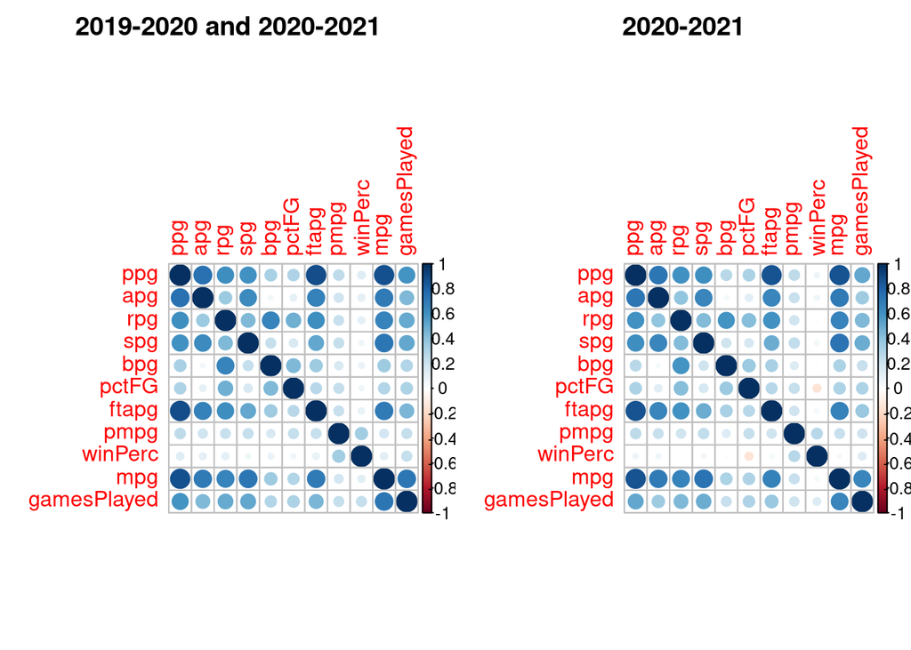

```r
par(mfrow=c(1, 2))
s2 <- cor(labeled_players[, 2:12])
corrplot(s2, title = "2019-2020 and 2020-2021", mar = c(2, 0, 2, 0))

s1 <- cor(current_season_set[, 2:12])
corrplot(s1, title = "2020-2021", mar = c(2, 0, 2, 0))
```

```r
# Let us normalize gamesPlayed (the only non normalized attribute with low correlation to performance attributes)
labeled_players$gamesPlayed <- labeled_players$gamesPlayed / max(labeled_players$gamesPlayed)
current_season_set$gamesPlayed <- current_season_set$gamesPlayed / max(current_season_set$gamesPlayed)
```

Let us now split our dataset into train and test -> 70% 30% split

```r
# Get our ratio of train to test
train_size = floor(nrow(labeled_players) * 0.70)

# Sample 75%. Seed so we can reproduce the same samplings
set.seed(123)
train_size <- sample(seq_len(nrow(labeled_players)), size = train_size, replace = FALSE)

# Allocate 75% to train and 20% to test
training_set <- labeled_players[train_size,]
test_set <- labeled_players[-train_size,]
```

Lets get an optimal K value for our KNN

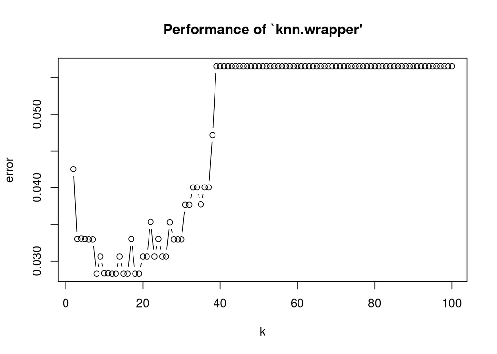

```r
# Drop column with player names
drop_names <- training_set[, -1]
# Drop column with labels
data_no_labels <- drop_names[, -12]

# Get the label column
labels <- drop_names[, 12]

# Do the cross validation to find optimal k
tuning <- tune.knn(data_no_labels, factor(labels), k = 2:100)

plot(tuning)
```

```r
cat("Cross Validated Optimal K: ", tuning$best.parameters[1,])
```

[output not shown]

execute our KNN model

```r
all_star_tr <- training_set$AllStar

for_training <- training_set[, -1]
for_training <- for_training[, -12]

for_testing <- test_set[, -1]
for_testing <- for_testing[, -12]

for_general <- current_season_set[, -1]
for_general <- for_general[, -12]

train_preds <- knn(train = for_training, test = for_training, cl = all_star_tr, k = tuning$best.parameters)
test_preds <- knn(train = for_training, test = for_testing, cl = all_star_tr, k = tuning$best.parameters)

full_set_preds <- knn(train = for_training, test = for_general, cl = all_star_tr, k = tuning$best.parameters)

cat('Training Accuracy: ', mean(train_preds == training_set$AllStar))
```

```
## Training Accuracy:  0.9717647
```

```r
table(train_preds, training_set$AllStar)
```

```
##
## train_preds   0   1
##           0 400  11
##           1   1  13
```

```r
cat('Test Accuracy: ', mean(test_preds == test_set$AllStar))
```

```
## Test Accuracy:  0.9945355
```

```r
table(test_preds, test_set$AllStar)
```

```
##
## test_preds   0   1
##          0 171   1
##          1   0  11
```

```r
cat('Current Season Accuracy 2020-2021: ', mean(full_set_preds == current_season_set$AllStar))
```

```
## Current Season Accuracy 2020-2021:  0.9815574
```

```r
table(full_set_preds, current_season_set$AllStar)
```

```
##
## full_set_preds   0   1
##              0 458   6
##              1   3  21
```

Let us filter out and see which all stars were not classified as all stars

```r
#prune <- labeled_players %>% select(playerName, AllStar)
prune <- current_season_set
prune$KNNPrediction <- full_set_preds

# Players that KNN said were not all stars that actually were
miss_classified <- prune %>% filter(prune$AllStar == 1)
miss_classified <- miss_classified %>% filter(miss_classified$KNNPrediction == 0)
miss_classified
```

```
##         playerName      ppg      apg       rpg       spg       bpg     pctFG
## 1      Ben Simmons 15.96552 7.862069  8.103448 1.5862069 0.7586207 0.5811724
## 2       Chris Paul 16.58065 8.774194  4.677419 1.2580645 0.2903226 0.4787419
## 3 Domantas Sabonis 21.37500 5.875000 11.406250 0.9687500 0.6250000 0.5341875
## 4      Mike Conley 16.22222 5.703704  3.555556 1.4814815 0.1111111 0.4417778
## 5   Nikola Vucevic 24.35294 3.617647 11.558824 1.0294118 0.6470588 0.4786176
## 6      Rudy Gobert 14.00000 1.264706 13.352941 0.4117647 2.7058824 0.6621471
##      ftapg      pmpg   winPerc      mpg gamesPlayed AllStar KNNPrediction
## 1 5.551724  4.689655 0.6896552 33.86207   0.8285714       1             0
## 2 2.548387  4.806452 0.6451613 32.03226   0.8857143       1             0
## 3 6.125000 -1.812500 0.4687500 36.46875   0.9142857       1             0
## 4 2.703704 10.888889 0.7407407 29.22222   0.7714286       1             0
## 5 2.558824 -6.882353 0.3823529 33.76471   0.9714286       1             0
## 6 5.441176  9.588235 0.7941176 30.32353   0.9714286       1             0
```

```r
# Players that KNN classified as all stars but were not
snubs <- prune %>% filter(prune$AllStar == 0)
snubs <- snubs %>% filter(snubs$KNNPrediction == 1)
snubs
```

```
##       playerName      ppg      apg       rpg       spg       bpg     pctFG
## 1 Christian Wood 22.00000 1.294118 10.235294 0.9411765 1.5294118 0.5664706
## 2    CJ McCollum 26.69231 5.000000  3.923077 1.3076923 0.3076923 0.4714615
## 3     Trae Young 26.83871 9.483871  4.096774 0.8064516 0.2580645 0.4307419
##      ftapg     pmpg   winPerc      mpg gamesPlayed AllStar KNNPrediction
## 1 3.764706 2.529412 0.4705882 31.29412   0.4857143       0             1
## 2 3.461538 4.615385 0.6153846 33.92308   0.3714286       0             1
## 3 9.838710 2.451613 0.4516129 34.74194   0.8857143       0             1
```

Let us model with an ANN and see if we can get better results

```r
sign.act.fct <- function(inputs) {
  return(ifelse(inputs>0.5, 1, 0))
}

nba_nn <- neuralnet(AllStar ~ ppg + apg + rpg + spg + bpg + pctFG + ftapg + pmpg + winPerc + mpg + gamesPlayed, data=training_set, hidden = 8, act.fct = sigmoid, linear.output = F)
```

Visualize the model

```r
plot(nba_nn, show.weights = F, col.entry = "red", col.hidden = "green", col.out = "blue", information = F)
```

[output not shown]

Predict on Test Set

```r
test_pred = compute(nba_nn, test_set)

# Run sign activation function on the results of the output layer
binary_test <- sign.act.fct(test_pred$net.result)

# Lets see our accuracy
test_v <- table(test_set$AllStar, binary_test)
cat("Test Accuracy: ", (test_v[1] + test_v[4]) / length(binary_test), "\n")
```

```
## Test Accuracy:  0.989071
```

```r
# Classify our full dataset
full_pred = compute(nba_nn, current_season_set)

binary_full <- sign.act.fct(full_pred$net.result)

full_v <- table(current_season_set$AllStar, binary_full)
cat("Current Season Accuracy 2020-2021: ", (full_v[1] + full_v[4]) / length(binary_full))
```

```
## Current Season Accuracy 2020-2021:  0.9651639
```

```r
#prune <- labeled_players %>% select(playerName, AllStar)
prune <- current_season_set
prune$ANNPrediction <- binary_full

# Who the ANN said shouldn't be all stars
miss_classified <- prune %>% filter(prune$AllStar == 1)
miss_classified <- miss_classified %>% filter(miss_classified$ANNPrediction == 0)
miss_classified
```

```
##        playerName      ppg      apg       rpg      spg       bpg     pctFG
## 1   Anthony Davis 22.52174 3.043478  8.391304 1.347826 1.7826087 0.5436522
## 2      Chris Paul 16.58065 8.774194  4.677419 1.258065 0.2903226 0.4787419
## 3  Nikola Vucevic 24.35294 3.617647 11.558824 1.029412 0.6470588 0.4786176
## 4 Zion Williamson 25.50000 3.343750  7.062500 0.906250 0.7187500 0.6272500
##      ftapg      pmpg   winPerc      mpg gamesPlayed AllStar ANNPrediction
## 1 5.652174  5.869565 0.7391304 32.86957   0.6571429       1             0
## 2 2.548387  4.806452 0.6451613 32.03226   0.8857143       1             0
## 3 2.558824 -6.882353 0.3823529 33.76471   0.9714286       1             0
## 4 7.937500  0.000000 0.4375000 32.87500   0.9142857       1             0
```

```r
# Who the ANN said should be all stars
snubs <- prune %>% filter(prune$AllStar == 0)
snubs <- snubs %>% filter(snubs$ANNPrediction == 1)
snubs
```

```
##            playerName      ppg      apg       rpg       spg       bpg     pctFG
## 1         Bam Adebayo 19.58065 5.516129  9.612903 0.9354839 1.0000000 0.5680968
## 2     Devonte' Graham 13.72000 5.680000  3.000000 1.0000000 0.0000000 0.3518400
## 3       Fred VanVleet 20.11765 6.588235  4.441176 1.7058824 0.7941176 0.3860882
## 4        Jamal Murray 21.58065 4.612903  4.354839 1.1290323 0.3225806 0.4664839
## 5        Jimmy Butler 20.14286 7.761905  7.761905 1.8571429 0.3809524 0.4186190
## 6   Jonas Valanciunas 16.25000 1.916667 11.333333 0.5833333 0.6666667 0.5562917
## 7  Karl-Anthony Towns 22.50000 4.214286 10.714286 0.9285714 1.8571429 0.5218571
## 8          Kevin Love  9.50000 2.500000  6.000000 0.5000000 0.0000000 0.3330000
## 9     Khris Middleton 20.60606 5.696970  6.090909 1.1212121 0.1818182 0.5131212
## 10         Kyle Lowry 18.03704 6.629630  5.666667 1.1851852 0.1851852 0.4857037
## 11    Malcolm Brogdon 21.35484 6.419355  4.806452 1.2258065 0.2580645 0.4404839
## 12      Pascal Siakam 20.06667 4.766667  7.466667 1.1666667 0.7000000 0.4459000
## 13         Trae Young 26.83871 9.483871  4.096774 0.8064516 0.2580645 0.4307419
##       ftapg       pmpg   winPerc      mpg gamesPlayed AllStar ANNPrediction
## 1  5.741935 -0.3225806 0.5161290 33.93548  0.88571429       0             1
## 2  2.840000  2.9200000 0.4400000 32.76000  0.71428571       0             1
## 3  3.882353  3.3529412 0.5000000 36.79412  0.97142857       0             1
## 4  3.548387  6.5483871 0.5806452 35.19355  0.88571429       0             1
## 5  8.285714  3.6190476 0.6190476 33.09524  0.60000000       0             1
## 6  3.625000  0.5833333 0.4583333 27.75000  0.68571429       0             1
## 7  4.785714 -0.2857143 0.2142857 32.71429  0.40000000       0             1
## 8  2.500000  9.0000000 1.0000000 23.50000  0.05714286       0             1
## 9  3.212121  5.2424242 0.6060606 33.36364  0.94285714       0             1
## 10 3.518519  2.4814815 0.4074074 34.37037  0.77142857       0             1
## 11 2.870968  0.2580645 0.4838710 35.96774  0.88571429       0             1
## 12 4.966667  2.2666667 0.4666667 35.86667  0.85714286       0             1
## 13 9.838710  2.4516129 0.4516129 34.74194  0.88571429       0             1
```

```r
weights <- neuralweights(nba_nn)
w_df <- data.frame(weights[2]$wts$`hidden 1 1`, weights[2]$wts$`hidden 1 2`, weights[2]$wts$`hidden 1 3`, weights[2]$wts$`hidden 1 4`, weights[2]$wts$`hidden 1 5`, weights[2]$wts$`hidden 1 6`, weights[2]$wts$`hidden 1 7`, weights[2]$wts$`hidden 1 8`)

emph <- rbind.data.frame(rowMeans(w_df))

tmp <- current_season_set[, -1]
tmp <- tmp[, -12]
names(emph) <- names(tmp)

t1 <- rowMeans(w_df)

cat("Top 5 Emphasized Variables when determining an All Star Player\n\n")
```

```
## Top 5 Emphasized Variables when determining an All Star Player
```

```r
cat("Variable : Weight\n-----------------\n")
```

```
## Variable : Weight
## -----------------
```

```r
for (weight1 in head(t1[order(-t1)], 5)) {
  i <- 1
  for (weight2 in emph[1,]) {
    if (weight1 == weight2) {
      cat(names(emph)[i], ": ", weight1, "\n")
    }
    i <- i + 1
  }
}
```

```
## pctFG :  21.38223
## pmpg :  18.88244
## gamesPlayed :  15.39113
## apg :  15.08325
## spg :  14.95466
```

Graphic

```r
#download.file(toString(playerImgs[1, 2]), 'test.png', mode = "wb")
#jj <- readPNG("test.png", native=T)
#jg <- readPNG("test.png", native=T)
#plot(c(0, 20), c(0, 5), type="n")
#rasterImage(jj, 0, 2, 5, 4)
#rasterImage(jj, 5, 2, 10, 4)

xleft <- 0
xright <- 5

generateLineup <- function(roster, imageDB) {
  display <- list()

  for (player1 in 1:nrow(roster)) {
    for (player2 in 1:nrow(playerImgs)) {
      if(roster[player1, "playerName"] == imageDB[player2,"pull_stats2.namePlayer"]) {
        download.file(toString(imageDB[player2, 'pull_stats2.urlPlayerHeadshot']), gsub(" ", "", paste(toString(imageDB[player2,"pull_stats2.namePlayer"]), ".png")), mode = "wb")
        display[[toString(roster[player1, "playerName"])]] <- gsub(" ", "", paste(toString(imageDB[player2,"pull_stats2.namePlayer"]), ".png"))
        break
      }
    }
  }
  return(display)
}

dis_snubs <- generateLineup(snubs, playerImgs)
dis_mis <- generateLineup(miss_classified, playerImgs)
```

## Display the players classified through ANN

Display Players that were snubbed from the All Star Game

[figure not shown]

[figure not shown]

[figure not shown]

[figure not shown]

[figure not shown]

[figure not shown]

[figure not shown]

[figure not shown]

[figure not shown]

[figure not shown]

[figure not shown]

[figure not shown]

[1 more figures not shown]

```r
for(img in dis_snubs) {
  plot(c(0, 10), c(0, 10), type="n", ann=T,axes=FALSE, main = gsub(".png", "",img), xlab = "", ylab = "")
  rasterImage(readPNG(img, native=T), 3.1, 4, 7.1, 10)
}
```

Display All Stars that were classified as non-allstars

[figure not shown]

[figure not shown]

[figure not shown]

[figure not shown]

```r
for(img in dis_mis) {
  plot(c(0, 10), c(0, 10), type="n", ann=T,axes=FALSE, main = gsub(".png", "",img), xlab = "", ylab = "")
  rasterImage(readPNG(img, native=T), 3.1, 4, 7.1, 10)
}
```

Clean

```r
for (img in dis_snubs) {
  file.remove(img)
}
for (img in dis_mis) {
  file.remove(img)
}
```